# What Does a Benford Test Actually Test? Reproducible benchmark — revision pass 3

Author

Arthur Charpentier

```
================ REPRODUCIBILITY SEEDS ================
Primary simulations       : 20260817
Rho sensitivity           : 20260818
Representative samples    : 20260819
Manipulation experiment   : 20260820
AUC bootstrap             : 20260821
Mixture composition       : 20260822
Multiplication game       : 20260831
Game: one-step washout    : 20260832
Game: non-Haar mixing     : 20260833
Pass 3: B/L sensitivity   : 20260901
Pass 3: CvM calibration   : 20260902
Pass 3: marginal power    : 20260903
Pass 3: boundary demo     : 20260904
=======================================================
Engine version             : 2026-08-17-v5.1-design-aware-robust
Design module              : 2026-08-17-pass2-design-aware-v1
Pass 3 module              : 2026-08-17-v1-size-cvm-power
```

# Design

The primary benchmark compares four processes whose population logarithmic significand (U={_{10}X}) is exactly uniform on ([0,1)). In v2, the latent-regime construction uses exactly half of the sequences in each conditional regime. This removes finite-sample noise from a randomly realized mixture weight and isolates the aggregation mechanism itself. A separate experiment below restores random sequence-level composition.

```r
design_table <- make_design_table(
  n_seq = params$n_seq,
  seq_len = params$seq_len,
  rho = params$rho,
  theta = params$theta
)

knitr::kable(design_table, format = "html")
```

| Construction | Benford target | Within-sequence structure | Parameters |
| --- | --- | --- | --- |
| iid Benford reference | marginally Benford at each observation | independent | 400 sequences x 250 |
| Stochastic multiplicative | marginally Benford at each observation | wrapped Gaussian random walk | rho = 0.50 |
| Deterministic rotation | marginally Benford under random phase | irrational rotation | theta = 0.618034 |
| Latent-regime mixture | pooled-Benford under fixed 50/50 weighting | conditionally iid given latent regime | exactly 50/50 sequences; Beta(2,1) / Beta(1,2) |

```r
save_latex_table(
  design_table,
  file.path(tab_dir, "table_design.tex"),
  caption = "Primary simulation design. All four constructions have an exact Benford population marginal; the latent-regime benchmark fixes the sequence composition at 50/50.",
  label = "tab:design"
)
```

# Primary Monte Carlo experiment

```r
if (isTRUE(params$recompute) || !file.exists(primary_file)) {
  primary <- run_primary_simulations(
    R = params$R_main,
    n_seq = params$n_seq,
    seq_len = params$seq_len,
    rho = params$rho,
    theta = params$theta,
    K_fourier = params$K_fourier,
    seed = SEED_PRIMARY,
    progress = TRUE
  )
  saveRDS(primary, primary_file)
} else {
  primary <- readRDS(primary_file)
}

if (isTRUE(params$recompute) || !file.exists(representative_file)) {
  representative <- make_representative_samples(
    n_seq = params$n_seq,
    seq_len = params$seq_len,
    rho = params$rho,
    theta = params$theta,
    seed = SEED_REPRESENTATIVE
  )
  saveRDS(representative, representative_file)
} else {
  representative <- readRDS(representative_file)
}
```

## Marginal first-digit agreement

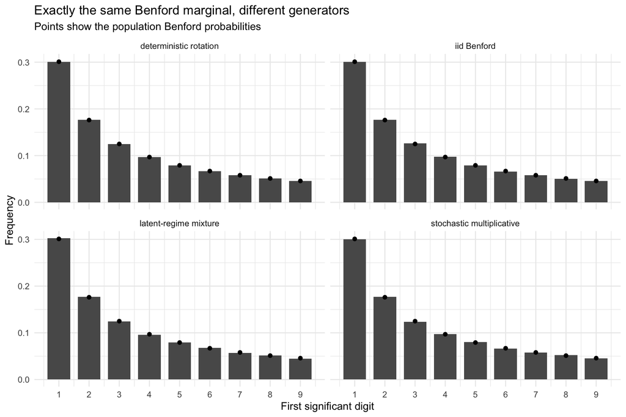

Figure 1: Representative first-digit frequencies. All four generators have the same exact population Benford marginal.

```r
p_digits <- plot_first_digits(representative)
p_digits
ggplot2::ggsave(
  file.path(fig_dir, "figure_first_digits.pdf"),
  p_digits, width = 9, height = 6
)
```

## Finite-sample behavior of the standard iid test

The dashed line below is the conventional 5% critical value of a (^2_8) reference law. The population first-digit probabilities are nevertheless exactly Benford in every construction. In the latent control, the number of sequences in the two non-Benford conditional regimes is fixed at exactly 50/50. Differences in rejection behavior therefore cannot be attributed to random fluctuations in the realized mixture weight.

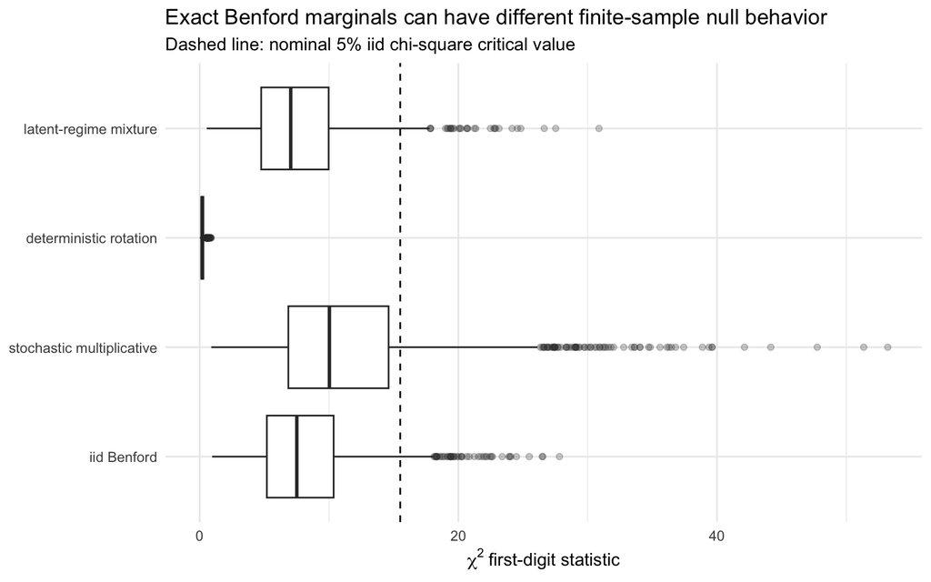

Figure 2: Sampling distribution of the conventional first-digit chi-square statistic.

```r
p_chi <- plot_chisq_distribution(primary)
p_chi
ggplot2::ggsave(
  file.path(fig_dir, "figure_chisq_sampling.pdf"),
  p_chi, width = 8, height = 5
)
```

## Sequence information

We use the complex first circular transition moment

[ m_1= *{s,t}{2i(U*{s,t+1}-U_{s,t})}. ]

This is computationally much cheaper and, importantly, removes the apparent transition coherence generated solely by persistent latent composition within a sequence.

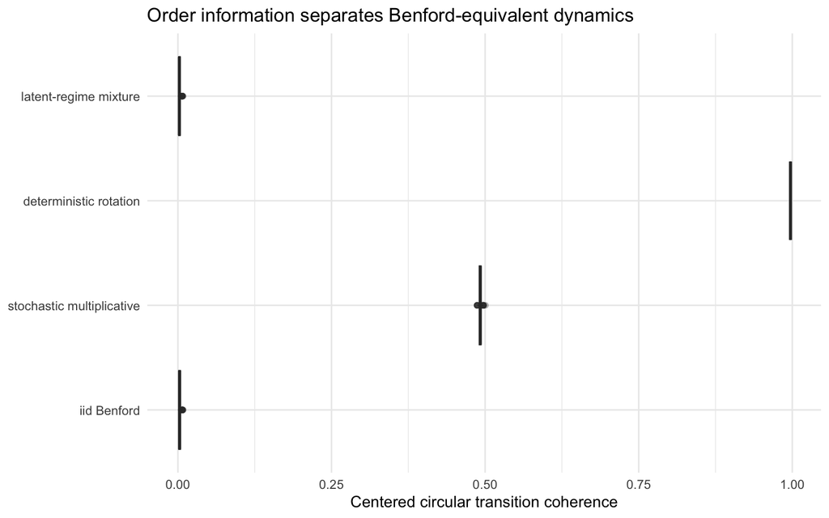

Figure 3: Centered circular transition coherence after exact within-sequence shuffle adjustment.

```r
p_trans <- plot_transition_coherence(primary)
p_trans
ggplot2::ggsave(
  file.path(fig_dir, "figure_transition_coherence.pdf"),
  p_trans, width = 8, height = 5
)
```

## Held-out summary table

```r
results_table <- summarize_primary_results(primary)
knitr::kable(results_table, format = "html")
```

| model | Chi-square | Reject (0.05) | CvM W2 | B(K) | C centered |
| --- | --- | --- | --- | --- | --- |
| iid Benford | 8.111 (4.086) | 0.052 | 0.1661 (0.1429) | 0.000050 (0.000022) | 0.003 (0.001) |
| stochastic multiplicative | 11.511 (6.620) | 0.216 | 0.3570 (0.3561) | 0.000070 (0.000036) | 0.492 (0.002) |
| deterministic rotation | 0.223 (0.132) | 0.000 | 0.0023 (0.0018) | 0.000001 (0.000001) | 0.997 (0.000) |
| latent-regime mixture | 7.676 (3.941) | 0.038 | 0.1329 (0.1079) | 0.000049 (0.000023) | 0.003 (0.001) |

```r
save_latex_table(
  results_table,
  file.path(tab_dir, "table_primary_results.tex"),
  caption = "Held-out Monte Carlo statistics. Entries are means with Monte Carlo standard deviations in parentheses, except the rejection rate.",
  label = "tab:primary-results"
)
```

## Analytical check for the mean Pearson statistic

Because the population first-digit probabilities are known exactly, the expected Pearson statistic can also be computed from the within-sequence covariance structure. For the wrapped-Gaussian process the covariance is obtained from the Fourier coefficients of the digit intervals; for the rotation it is obtained from exact circular interval overlaps; and for the balanced latent mixture it follows from stratified multinomial variation. This gives a direct theory-versus-simulation check rather than relying on Monte Carlo alone.

```r
chisq_theory <- make_chisq_theory_table(
  primary, rho = params$rho, theta = params$theta, seq_len = params$seq_len
)
knitr::kable(chisq_theory, digits = 4, format = "html")
```

| Construction | Theoretical E[chi-square] | Monte Carlo mean | MC minus theory |
| --- | --- | --- | --- |
| iid Benford | 8.0000 | 8.1108 | 0.1108 |
| stochastic multiplicative | 11.7106 | 11.5110 | -0.1996 |
| deterministic rotation | 0.2187 | 0.2228 | 0.0040 |
| latent-regime mixture | 7.6789 | 7.6765 | -0.0025 |

```r
save_latex_table(
  chisq_theory,
  file.path(tab_dir, "table_chisq_theory.tex"),
  caption = "Analytical expectation of the first-digit Pearson statistic and held-out Monte Carlo means.",
  label = "tab:chisq-theory",
  digits = 4
)
```

## Design-aware calibration of the same Pearson discrepancy

The classical Pearson statistic is kept fixed; what changes is its reference law. Let (p_8) denote the first eight empirical digit proportions and let (p_8) denote their Benford targets. With the ninth cell determined by the unit-sum constraint,

[ X_n^2 = n(p_8-p_8)^ A (p_8-p_8), A=(p_1<sup>{-1},,p_8</sup>{-1})+p_9^{-1}^. ]

The independent sequences provide a direct estimate of (={n(p_8-p_8)}). For equal sequence length (L), this is (L) times the covariance of the sequence-level digit proportions. In the exactly balanced latent design we estimate covariance *within* latent strata and combine it using the fixed 50/50 design weights; otherwise random composition would incorrectly be treated as part of the sampling design that was fixed by construction.

If (_1,,_8) are the eigenvalues of (A^{1/2}A^{1/2}), the iid multinomial reference corresponds to (_j=1) for all (j). We report three design-aware calibrations:

1. a first-order design-effect correction, dividing (X_n^2) by ();
2. a second-order Satterthwaite/Rao–Scott-style correction, [ a=, =, X_n<sup>2/a</sup>2_; ]
3. a sequence-aware Wald statistic using () directly.

The point is not to claim a universal Benford correction. These procedures are valid only to the extent that the declared independent-sequence structure is the relevant observation design. They provide a constructive check of the paper’s central claim: when the design is retained, the same discrepancy can be calibrated against the appropriate sampling variability rather than against an iid multinomial law.

```r
calibration_table <- summarize_design_aware_calibration(primary)
knitr::kable(calibration_table, digits = 4, format = "html")
```

| model | Naive Pearson | RS first-order | RS second-order | Sequence Wald | Mean design effect | Mean RS2 df |
| --- | --- | --- | --- | --- | --- | --- |
| iid Benford | 0.0520 | 0.0520 | 0.0505 | 0.0615 | 1.0003 | 7.8293 |
| stochastic multiplicative | 0.2165 | 0.0655 | 0.0475 | 0.0560 | 1.4632 | 6.2213 |
| deterministic rotation | 0.0000 | 0.0795 | 0.0510 | 0.0545 | 0.0274 | 5.0803 |
| latent-regime mixture | 0.0385 | 0.0500 | 0.0455 | 0.0640 | 0.9611 | 7.7055 |

```r
save_latex_table(
  calibration_table,
  file.path(tab_dir, "table_design_aware_calibration.tex"),
  caption = "Monte Carlo rejection rates at nominal 5 percent under the iid Pearson reference and three sequence-aware calibrations. The balanced latent design uses within-regime covariance because its 50/50 composition is fixed by design.",
  label = "tab:design-aware-calibration",
  digits = 4
)
```

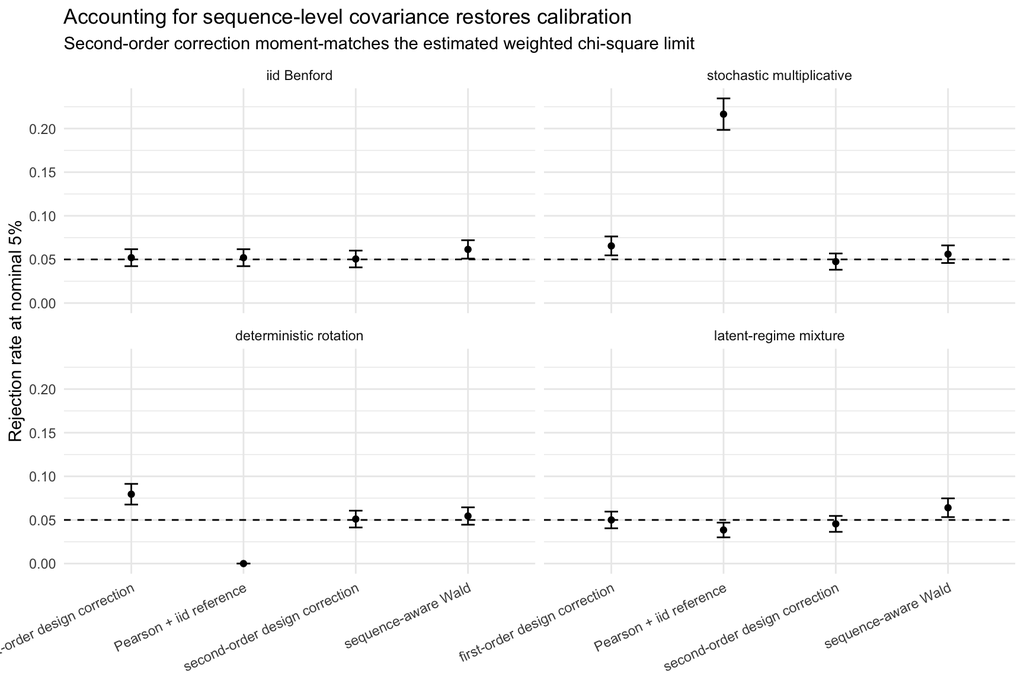

Figure 4: Nominal 5% rejection rates before and after sequence-level design correction.

```r
p_cal <- plot_design_aware_rejection(primary)
p_cal
ggplot2::ggsave(
  file.path(fig_dir, "figure_design_aware_calibration.pdf"),
  p_cal, width = 9, height = 6
)
```

The estimated design-effect spectrum is also informative in its own right. Its mean controls the first-order inflation/deflation of Pearson’s statistic, while dispersion of the eigenvalues determines how inadequate a single scalar correction can be.

```r
spectrum_table <- summarize_design_spectrum(primary)
knitr::kable(spectrum_table, digits = 4, format = "html")
```

| model | Mean lambda | SD mean lambda | Mean max lambda | Mean RS2 scale | Mean RS2 df |
| --- | --- | --- | --- | --- | --- |
| iid Benford | 1.0003 | 0.0240 | 1.2396 | 1.0222 | 7.8293 |
| stochastic multiplicative | 1.4632 | 0.0402 | 2.9867 | 1.8835 | 6.2213 |
| deterministic rotation | 0.0274 | 0.0007 | 0.0711 | 0.0431 | 5.0803 |
| latent-regime mixture | 0.9611 | 0.0287 | 1.2485 | 0.9979 | 7.7055 |

```r
save_latex_table(
  spectrum_table,
  file.path(tab_dir, "table_design_effect_spectrum.tex"),
  caption = "Estimated sequence-level design-effect spectrum underlying the Pearson quadratic form.",
  label = "tab:design-effect-spectrum",
  digits = 4
)
```

## Pairwise ordinal discrimination

The signed effect is (2,-1). Its sign records ordering; its magnitude records univariate separation across Monte Carlo replications.

```r
auc_table <- pairwise_auc_results(
  primary,
  statistics = c("chisq", "cvm", "B_K", "C_centered"),
  B = params$auc_bootstrap,
  seed = SEED_AUC
)
auc_table$estimate <- sprintf(
  "%.3f [%.3f, %.3f]",
  auc_table$effect, auc_table$lo, auc_table$hi
)
auc_display <- auc_table[, c("statistic", "comparison", "estimate")]
auc_display$statistic <- c(
  chisq = "chi-square", cvm = "CvM", B_K = "B(K)", C_centered = "C centered"
)[auc_display$statistic]
knitr::kable(auc_display, format = "html")
```

| statistic | comparison | estimate |
| --- | --- | --- |
| chi-square | iid Benford vs stochastic multiplicative | 0.320 [0.287, 0.354] |
| chi-square | iid Benford vs deterministic rotation | -1.000 [-1.000, -1.000] |
| chi-square | iid Benford vs latent-regime mixture | -0.062 [-0.101, -0.027] |
| chi-square | stochastic multiplicative vs deterministic rotation | -1.000 [-1.000, -1.000] |
| chi-square | stochastic multiplicative vs latent-regime mixture | -0.372 [-0.402, -0.340] |
| chi-square | deterministic rotation vs latent-regime mixture | 1.000 [1.000, 1.000] |
| CvM | iid Benford vs stochastic multiplicative | 0.405 [0.374, 0.437] |
| CvM | iid Benford vs deterministic rotation | -1.000 [-1.000, -1.000] |
| CvM | iid Benford vs latent-regime mixture | -0.134 [-0.167, -0.100] |
| CvM | stochastic multiplicative vs deterministic rotation | -1.000 [-1.000, -1.000] |
| CvM | stochastic multiplicative vs latent-regime mixture | -0.515 [-0.542, -0.486] |
| CvM | deterministic rotation vs latent-regime mixture | 1.000 [1.000, 1.000] |
| B(K) | iid Benford vs stochastic multiplicative | 0.350 [0.318, 0.382] |
| B(K) | iid Benford vs deterministic rotation | -1.000 [-1.000, -1.000] |
| B(K) | iid Benford vs latent-regime mixture | -0.048 [-0.083, -0.011] |
| B(K) | stochastic multiplicative vs deterministic rotation | -1.000 [-1.000, -1.000] |
| B(K) | stochastic multiplicative vs latent-regime mixture | -0.384 [-0.415, -0.350] |
| B(K) | deterministic rotation vs latent-regime mixture | 1.000 [1.000, 1.000] |
| C centered | iid Benford vs stochastic multiplicative | 1.000 [1.000, 1.000] |
| C centered | iid Benford vs deterministic rotation | 1.000 [1.000, 1.000] |
| C centered | iid Benford vs latent-regime mixture | -0.109 [-0.144, -0.070] |
| C centered | stochastic multiplicative vs deterministic rotation | 1.000 [1.000, 1.000] |
| C centered | stochastic multiplicative vs latent-regime mixture | -1.000 [-1.000, -1.000] |
| C centered | deterministic rotation vs latent-regime mixture | -1.000 [-1.000, -1.000] |

```r
save_latex_table(
  auc_display,
  file.path(tab_dir, "table_pairwise_auc.tex"),
  caption = "Signed pairwise AUC effects with percentile bootstrap intervals.",
  label = "tab:pairwise-auc"
)
```

# Conditioning reveals the latent-regime construction

The latent model uses (UZ=0(2,1)) and (UZ=1(1,2)). In the primary v2 benchmark, exactly half of the sequences are assigned to each regime. Neither conditional law is Benford, while the corresponding equal-weight pooled population is exactly uniform.

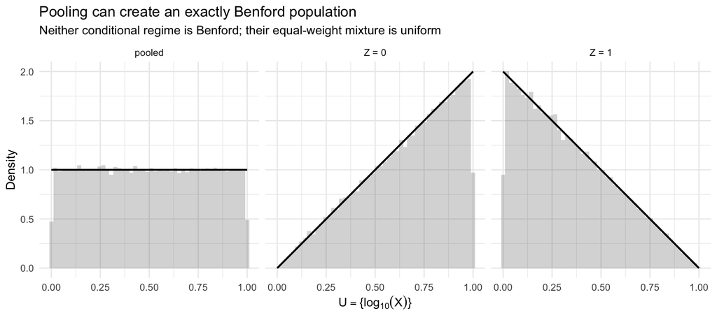

Figure 5: Non-Benford conditional regimes can pool to an exactly Benford population.

```r
p_mix <- plot_latent_mixture(representative$mixture)
p_mix
ggplot2::ggsave(
  file.path(fig_dir, "figure_latent_mixture.pdf"),
  p_mix, width = 9, height = 4
)
```

# Random cluster composition as a separate observation-design effect

The balanced latent control isolates aggregation from a second effect that appeared in the first numerical version. If sequence-level regimes are instead drawn independently,

[ Z_s(1/2), ]

the *superpopulation* mixture remains exactly Benford, but a realized dataset contains a random fraction () of the two regimes. Conditional on that realized composition, the pooled density is

[ f(u) =,2u+(1-),2(1-u) =1+2(/2)(2u-1). ]

Thus a conventional iid Benford test can react strongly to random cluster composition even though the population mixing mechanism itself has exactly equal weights. We keep this effect out of the primary benchmark and study it separately here.

```r
if (isTRUE(params$recompute) || !file.exists(composition_file)) {
  composition <- run_mixture_composition_simulations(
    R = params$R_composition,
    n_seq = params$n_seq,
    seq_len = params$seq_len,
    K_fourier = params$K_fourier,
    seed = SEED_COMPOSITION,
    progress = TRUE
  )
  saveRDS(composition, composition_file)
} else {
  composition <- readRDS(composition_file)
}

composition_summary <- summarize_mixture_composition(composition)
knitr::kable(composition_summary, digits = 4, format = "html")
```

| design | Mean pi-hat | SD pi-hat | Chi-square | Reject (0.05) | CvM W2 | B(K) |
| --- | --- | --- | --- | --- | --- | --- |
| balanced 50/50 | 0.5000 | 0.0000 | 7.431 (3.800) | 0.036 | 0.1306 (0.1042) | 0.000048 (0.000021) |
| random Bernoulli composition | 0.4998 | 0.0253 | 89.459 (111.132) | 0.760 | 8.6255 (11.5111) | 0.000426 (0.000512) |

```r
save_latex_table(
  composition_summary,
  file.path(tab_dir, "table_mixture_composition.tex"),
  caption = "Balanced versus random sequence-level composition in the latent-regime construction.",
  label = "tab:mixture-composition",
  digits = 4
)
```

The same covariance correction can be applied to the random-composition experiment. For the Bernoulli design, the sequence-level covariance deliberately includes between-regime composition variation, because that variation is part of the stated superpopulation sampling mechanism. For the fixed 50/50 control it does not.

```r
composition_calibration <- summarize_mixture_composition_calibration(composition)
knitr::kable(composition_calibration, digits = 4, format = "html")
```

| design | Mean pi-hat | SD pi-hat | Naive Pearson reject | RS first-order reject | RS second-order reject | Sequence Wald reject | Mean design effect | Mean RS2 df |
| --- | --- | --- | --- | --- | --- | --- | --- | --- |
| balanced 50/50 | 0.5000 | 0.0000 | 0.036 | 0.045 | 0.0425 | 0.054 | 0.9601 | 7.7065 |
| random Bernoulli composition | 0.4998 | 0.0253 | 0.760 | 0.162 | 0.0500 | 0.061 | 10.9927 | 1.1786 |

```r
save_latex_table(
  composition_calibration,
  file.path(tab_dir, "table_mixture_composition_calibration.tex"),
  caption = "Naive and design-aware rejection rates for fixed versus random latent-regime composition.",
  label = "tab:mixture-composition-calibration",
  digits = 4
)
```

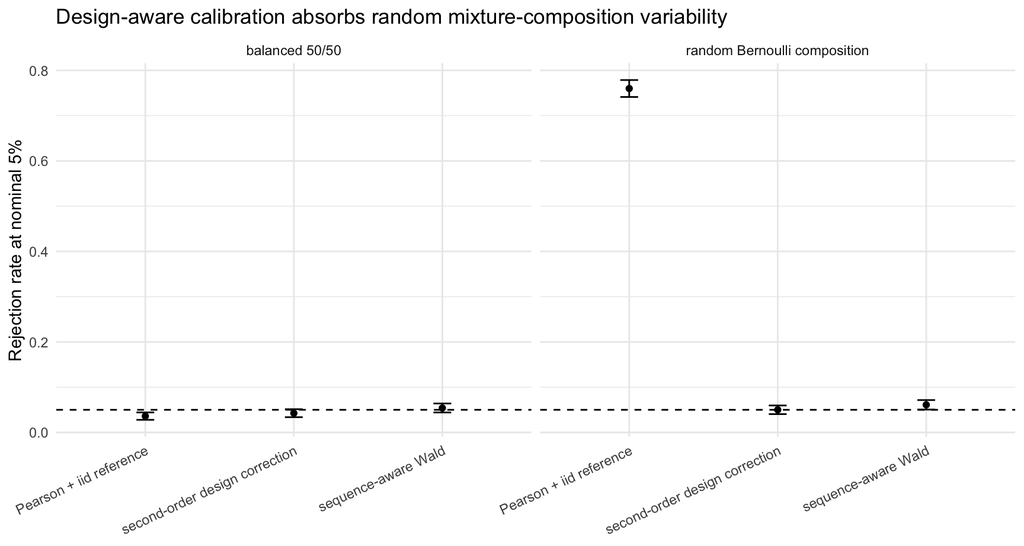

Figure 6: Design-aware calibration separates random composition variability from marginal nonconformity.

```r
p_comp_cal <- plot_mixture_composition_calibration(composition)
p_comp_cal
ggplot2::ggsave(
  file.path(fig_dir, "figure_mixture_composition_calibration.pdf"),
  p_comp_cal, width = 9, height = 4.8
)
```

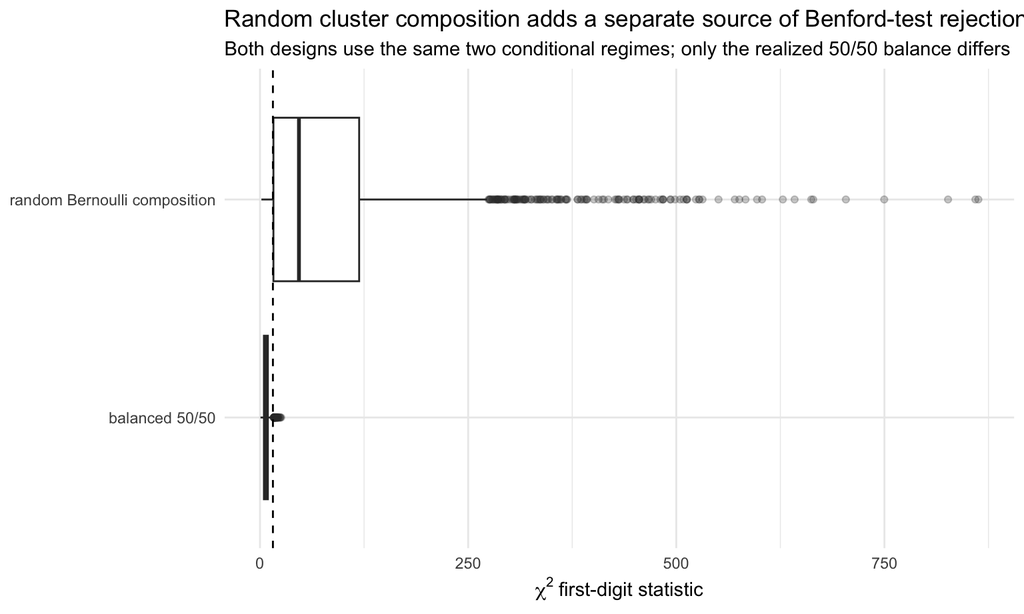

Figure 7: Separating the latent aggregation mechanism from random cluster-composition noise.

```r
p_comp_chi <- plot_mixture_composition_chisq(composition)
p_comp_chi
ggplot2::ggsave(
  file.path(fig_dir, "figure_mixture_composition_chisq.pdf"),
  p_comp_chi, width = 8, height = 4.8
)
```

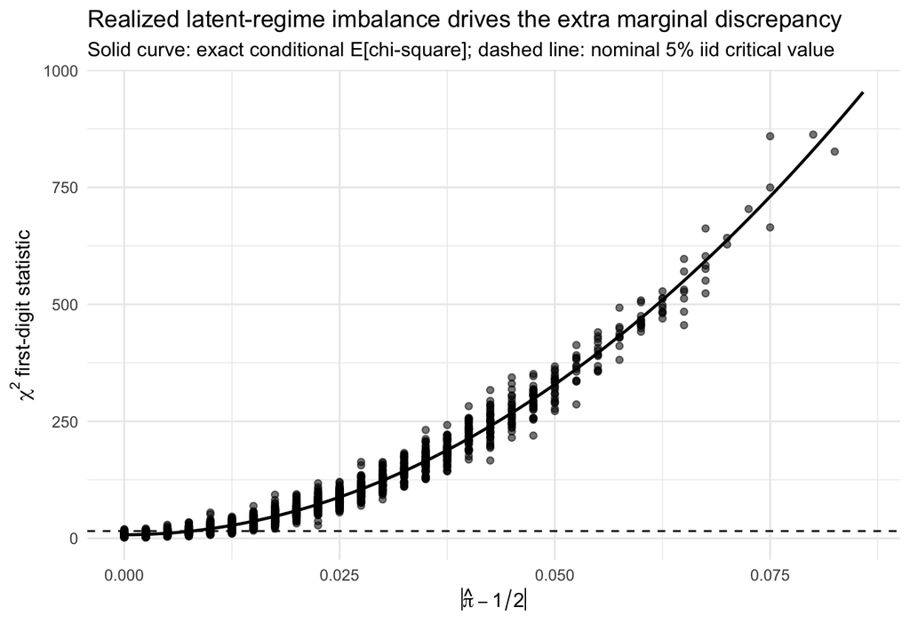

Figure 8: First-digit discrepancy against the realized imbalance in latent sequence composition.

```r
p_comp_imb <- plot_mixture_composition_imbalance(composition, n_total = params$n_seq * params$seq_len)
p_comp_imb
ggplot2::ggsave(
  file.path(fig_dir, "figure_mixture_composition_imbalance.pdf"),
  p_comp_imb, width = 7, height = 4.8
)
```

# Sensitivity to stochastic dependence

For the wrapped-Gaussian random walk, the first circular Fourier coefficient of the innovation kernel is parameterized as

[ =(-2<sup>2</sup>2). ]

Changing () therefore changes dependence while leaving the population Benford marginal exactly unchanged.

```r
rho_grid <- c(0, 0.1, 0.25, 0.5, 0.75, 0.9)
if (isTRUE(params$recompute) || !file.exists(sensitivity_file)) {
  sensitivity <- run_rho_sensitivity(
    rho_grid = rho_grid,
    R = params$R_sensitivity,
    n_seq = params$n_seq,
    seq_len = params$seq_len,
    K_fourier = params$K_fourier,
    seed = SEED_SENSITIVITY,
    progress = TRUE
  )
  saveRDS(sensitivity, sensitivity_file)
} else {
  sensitivity <- readRDS(sensitivity_file)
}

sens_summary <- summarize_rho_sensitivity(sensitivity)
knitr::kable(sens_summary, digits = 4, format = "html")
```

| rho | rejection_rate | rejection_se | rejection_rs1 | rejection_rs1_se | rejection_rs2 | rejection_rs2_se | rejection_wald | rejection_wald_se | mean_chisq | mean_lambda | mean_rs2_df | mean_C | se_C |
| --- | --- | --- | --- | --- | --- | --- | --- | --- | --- | --- | --- | --- | --- |
| 0.00 | 0.053 | 0.0071 | 0.048 | 0.0068 | 0.047 | 0.0067 | 0.062 | 0.0076 | 8.0827 | 0.9990 | 7.8284 | 0.0028 | 0e+00 |
| 0.10 | 0.073 | 0.0082 | 0.057 | 0.0073 | 0.055 | 0.0072 | 0.068 | 0.0080 | 8.3575 | 1.0489 | 7.7795 | 0.0990 | 1e-04 |
| 0.25 | 0.102 | 0.0096 | 0.051 | 0.0070 | 0.047 | 0.0067 | 0.056 | 0.0073 | 9.3976 | 1.1493 | 7.4724 | 0.2473 | 1e-04 |
| 0.50 | 0.220 | 0.0131 | 0.057 | 0.0073 | 0.047 | 0.0067 | 0.055 | 0.0072 | 11.5226 | 1.4634 | 6.2110 | 0.4921 | 1e-04 |
| 0.75 | 0.565 | 0.0157 | 0.092 | 0.0091 | 0.053 | 0.0071 | 0.059 | 0.0075 | 20.2883 | 2.4862 | 4.4234 | 0.7263 | 0e+00 |
| 0.90 | 0.871 | 0.0106 | 0.096 | 0.0093 | 0.047 | 0.0067 | 0.052 | 0.0070 | 45.2764 | 5.6867 | 3.5212 | 0.8305 | 1e-04 |

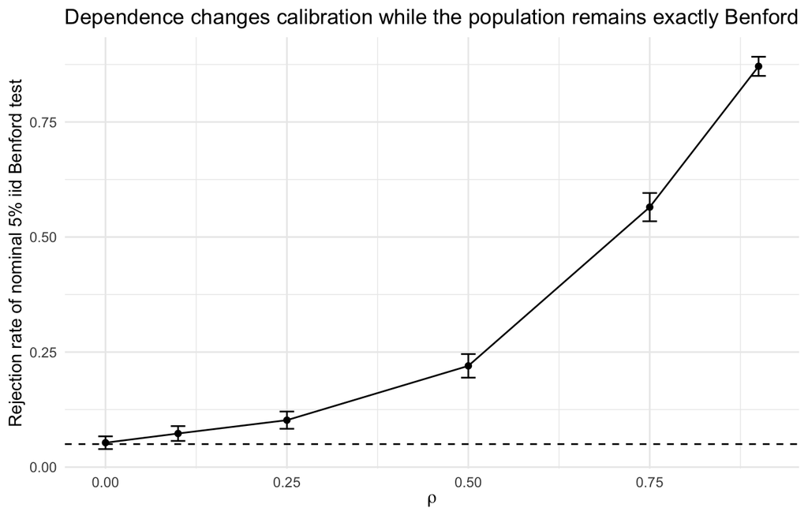

Figure 9: Nominal 5% rejection rate as dependence increases while the population remains exactly Benford.

```r
p_rho_rej <- plot_rho_rejection(sens_summary)
p_rho_rej
ggplot2::ggsave(
  file.path(fig_dir, "figure_rho_rejection.pdf"),
  p_rho_rej, width = 7, height = 4.5
)
```

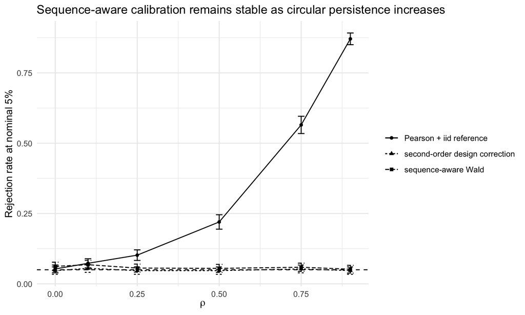

Figure 10: Naive and sequence-aware rejection rates across the circular-persistence parameter.

```r
p_rho_cal <- plot_rho_calibration_comparison(sens_summary)
p_rho_cal
ggplot2::ggsave(
  file.path(fig_dir, "figure_rho_calibration_comparison.pdf"),
  p_rho_cal, width = 8, height = 4.8
)
```

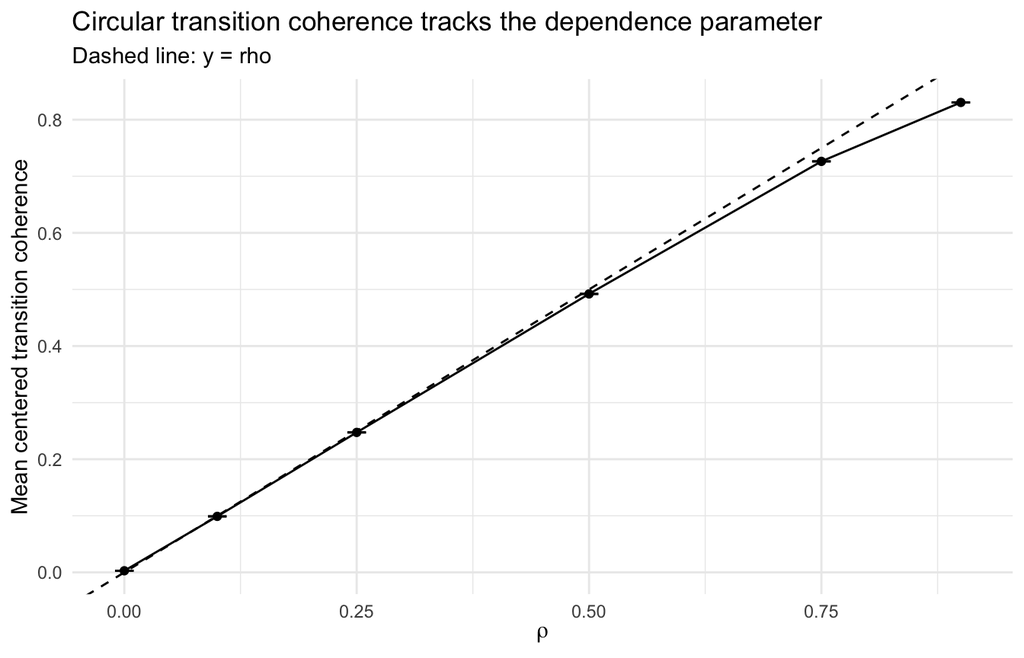

Figure 11: Centered circular transition coherence across the persistence parameter.

```r
p_rho_c <- plot_rho_coherence(sens_summary)
p_rho_c
ggplot2::ggsave(
  file.path(fig_dir, "figure_rho_coherence.pdf"),
  p_rho_c, width = 7, height = 4.5
)
```

# Pass 3A: Does the result depend on the choice n = 100,000?

The primary benchmark intentionally uses a large sample so that the iid Pearson reference is not compromised by sparse expected cells. A legitimate concern is that the calibration effect might therefore be an artifact of that particular choice. We separate three quantities: the number of independent sequences (B), their length (L), and the total number of records (n=BL).

Two complementary grids are used for the wrapped-Gaussian circular Markov construction at (). In the first, (B=400) is fixed and (L) varies, so total sample size changes while the number of independent sampling units does not. In the second, (n=100{,}000) is fixed while (B) and (L) trade off. This distinguishes a large-(n) effect from a cluster-length/design effect.

```r
pass3_design_grid <- default_pass3_design_grid()

if (isTRUE(params$recompute_pass3) || !file.exists(pass3_design_file)) {
  pass3_design <- run_design_size_sensitivity(
    R = params$R_design_sensitivity,
    design_grid = pass3_design_grid,
    rho = params$rho,
    seed = SEED_PASS3_DESIGN,
    progress = TRUE
  )
  saveRDS(pass3_design, pass3_design_file)
} else {
  pass3_design <- readRDS(pass3_design_file)
}

pass3_design_summary <- summarize_design_size_sensitivity(pass3_design)
knitr::kable(pass3_design_summary, digits = 4)
```

| experiment | design_id | n_seq | seq_len | n_total | Pearson iid | RS first-order | RS second-order | Sequence Wald | Mean design effect | Mean RS2 df |
| --- | --- | --- | --- | --- | --- | --- | --- | --- | --- | --- |
| Fixed B = 400; vary L and n | B400_L10 | 400 | 10 | 4e+03 | 0.196 | 0.046 | 0.038 | 0.072 | 1.3749 | 6.5632 |
| Fixed B = 400; vary L and n | B400_L100 | 400 | 100 | 4e+04 | 0.268 | 0.082 | 0.064 | 0.056 | 1.4558 | 6.2480 |
| Fixed B = 400; vary L and n | B400_L25 | 400 | 25 | 1e+04 | 0.250 | 0.054 | 0.048 | 0.064 | 1.4321 | 6.3395 |
| Fixed B = 400; vary L and n | B400_L250 | 400 | 250 | 1e+05 | 0.212 | 0.078 | 0.058 | 0.058 | 1.4623 | 6.2139 |
| Fixed B = 400; vary L and n | B400_L50 | 400 | 50 | 2e+04 | 0.202 | 0.060 | 0.054 | 0.062 | 1.4497 | 6.2622 |
| Fixed n = 100,000; vary B and L | B1000_L100 | 1000 | 100 | 1e+05 | 0.210 | 0.054 | 0.048 | 0.040 | 1.4606 | 6.2780 |
| Fixed n = 100,000; vary B and L | B100_L1000 | 100 | 1000 | 1e+05 | 0.234 | 0.062 | 0.046 | 0.094 | 1.4694 | 5.9356 |
| Fixed n = 100,000; vary B and L | B2000_L50 | 2000 | 50 | 1e+05 | 0.204 | 0.062 | 0.042 | 0.044 | 1.4501 | 6.3471 |
| Fixed n = 100,000; vary B and L | B200_L500 | 200 | 500 | 1e+05 | 0.212 | 0.052 | 0.042 | 0.060 | 1.4675 | 6.1087 |
| Fixed n = 100,000; vary B and L | B400_L250 | 400 | 250 | 1e+05 | 0.234 | 0.064 | 0.048 | 0.054 | 1.4612 | 6.2073 |

```r
save_latex_table(
  pass3_design_summary,
  file.path(tab_dir, "table_pass3_design_size_sensitivity.tex"),
  caption = "Sensitivity of nominal 5% rejection rates to the number of independent sequences B, sequence length L, and total sample size n=BL in the wrapped-Gaussian circular Markov construction (rho=0.5).",
  label = "tab:pass3-design-size"
)
```

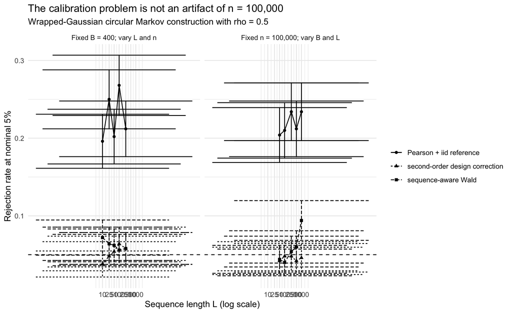

Figure 12: Rejection rates when sequence length, the number of independent sequences, and total sample size are varied separately.

```r
p_pass3_design <- plot_design_size_sensitivity(pass3_design)
p_pass3_design
ggplot2::ggsave(
  file.path(fig_dir, "figure_pass3_design_size_sensitivity.pdf"),
  p_pass3_design, width = 9, height = 5.5
)
```

# Pass 3B: A continuous-significand goodness-of-fit statistic

Pearson’s statistic uses only the nine first-digit cells. To check that the calibration issue is not tied to this discretization, we also use a Cramér–von Mises statistic for the continuous log-significand distribution,

[ W_n<sup>2=n_0</sup>1{F_n(u)-u}^2,du. ]

The code evaluates the integral on a fixed interior grid. Under iid Uniform sampling, the standard asymptotic 5% critical value is approximately 0.461. For design-aware calibration, the covariance of the sequence-level empirical CDF is estimated on the same grid. The resulting quadratic form again has a weighted-chi-square limit, so we use the same second-order moment-matching principle as for Pearson. This is an intentionally simple check of generality, not a claim that this discretized implementation is an optimal CvM procedure.

```r
if (isTRUE(params$recompute_pass3) || !file.exists(pass3_cvm_file)) {
  pass3_cvm <- run_cvm_calibration_experiment(
    R = params$R_cvm,
    n_seq = params$n_seq,
    seq_len = params$seq_len,
    rho = params$rho,
    theta = params$theta,
    grid_n = params$cvm_grid_n,
    seed = SEED_PASS3_CVM,
    progress = TRUE
  )
  saveRDS(pass3_cvm, pass3_cvm_file)
} else {
  pass3_cvm <- readRDS(pass3_cvm_file)
}

pass3_cvm_summary <- summarize_cvm_calibration(pass3_cvm)
knitr::kable(pass3_cvm_summary, digits = 4)
```

| model | CvM + iid reference | CvM + design correction | Mean CvM statistic | Mean RS2 df |
| --- | --- | --- | --- | --- |
| deterministic rotation | 0.000 | 0.044 | 0.0024 | 3.4610 |
| iid Benford | 0.056 | 0.062 | 0.1687 | 2.4955 |
| latent-regime mixture | 0.030 | 0.064 | 0.1398 | 3.2206 |
| stochastic multiplicative | 0.222 | 0.048 | 0.3458 | 1.9884 |

```r
save_latex_table(
  pass3_cvm_summary,
  file.path(tab_dir, "table_pass3_cvm_calibration.tex"),
  caption = "Nominal 5% rejection rates for a continuous-log-significand Cramer--von Mises statistic under the conventional iid reference and a sequence-aware second-order covariance calibration.",
  label = "tab:pass3-cvm"
)
```

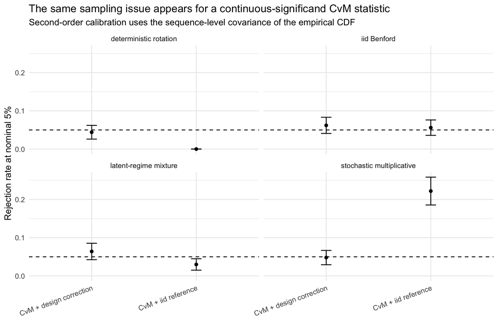

Figure 13: Naive and design-aware calibration of a continuous-log-significand Cramér–von Mises statistic.

```r
p_pass3_cvm <- plot_cvm_calibration(pass3_cvm)
p_pass3_cvm
ggplot2::ggsave(
  file.path(fig_dir, "figure_pass3_cvm_calibration.pdf"),
  p_pass3_cvm, width = 8.5, height = 5.5
)
```

# Pass 3C: Level and power under a genuine marginal alternative

The previous experiments keep the Benford marginal exactly correct and study size. To show that design correction is not synonymous with discarding marginal information, we also introduce a smooth one-parameter departure from uniformity,

[ f_(u)=1+(2u-1),. ]

Its CDF is (F_(u)=(1-)u+u^2). We generate the same () circular Markov process on a latent uniform scale and apply (F_^{-1}) pointwise. Thus () is exactly the dependent Benford null, while (>0) changes the one-time marginal without changing the underlying latent sequence construction. The experiment compares the inflated iid references with the design-aware Pearson and CvM procedures.

```r
pass3_epsilon_grid <- c(0, 0.005, 0.01, 0.02, 0.03, 0.05)

if (isTRUE(params$recompute_pass3) || !file.exists(pass3_power_file)) {
  pass3_power <- run_marginal_power_experiment(
    epsilon_grid = pass3_epsilon_grid,
    R = params$R_power,
    n_seq = params$n_seq,
    seq_len = params$seq_len,
    rho = params$rho,
    cvm_grid_n = params$cvm_grid_n,
    seed = SEED_PASS3_POWER,
    progress = TRUE
  )
  saveRDS(pass3_power, pass3_power_file)
} else {
  pass3_power <- readRDS(pass3_power_file)
}

pass3_power_summary <- summarize_marginal_power(pass3_power)
knitr::kable(pass3_power_summary, digits = 4)
```

| epsilon | Pearson iid | Pearson RS2 | Pearson Wald | CvM iid | CvM design |
| --- | --- | --- | --- | --- | --- |
| 0.000 | 0.246 | 0.064 | 0.074 | 0.250 | 0.060 |
| 0.005 | 0.278 | 0.072 | 0.072 | 0.332 | 0.092 |
| 0.010 | 0.406 | 0.118 | 0.122 | 0.542 | 0.210 |
| 0.020 | 0.734 | 0.438 | 0.412 | 0.878 | 0.628 |
| 0.030 | 0.964 | 0.830 | 0.796 | 0.994 | 0.934 |
| 0.050 | 1.000 | 1.000 | 1.000 | 1.000 | 1.000 |

```r
save_latex_table(
  pass3_power_summary,
  file.path(tab_dir, "table_pass3_marginal_power.tex"),
  caption = "Rejection probabilities under the smooth marginal alternative f_epsilon(u)=1+epsilon(2u-1), with the same latent rho=0.5 circular Markov dependence in every row.",
  label = "tab:pass3-power"
)
```

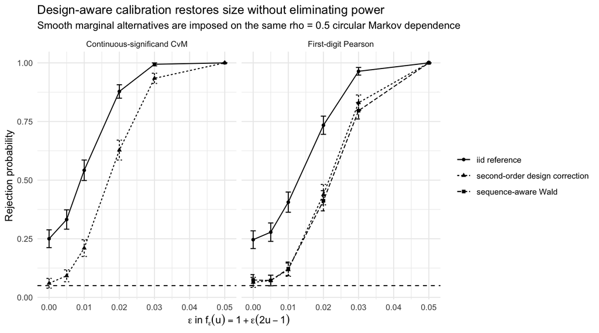

Figure 14: Size and power under a smooth departure from the Benford log-significand marginal.

```r
p_pass3_power <- plot_marginal_power(pass3_power)
p_pass3_power
ggplot2::ggsave(
  file.path(fig_dir, "figure_pass3_marginal_power.pdf"),
  p_pass3_power, width = 9, height = 5
)
```

## A positive control for the information-boundary discussion

The significand-preserving order shift later in the document is an impossibility construction: by definition it leaves every log-significand unchanged. To avoid suggesting that digit analysis is never informative, we add a deliberately simple positive control. A small amount of round-number heaping moves observations toward powers of ten and hence changes the log-significand distribution. The same digit statistics that are exactly blind to integer-order magnitude shifts react strongly when the observed representation itself changes.

```r
if (isTRUE(params$recompute_pass3) || !file.exists(pass3_boundary_file)) {
  pass3_boundary <- run_manipulation_boundary_demo(
    n_seq = params$n_seq,
    seq_len = params$seq_len,
    seed = SEED_PASS3_BOUNDARY
  )
  saveRDS(pass3_boundary, pass3_boundary_file)
} else {
  pass3_boundary <- readRDS(pass3_boundary_file)
}

knitr::kable(pass3_boundary, digits = 6)
```

| mechanism | pearson | pearson_p | cvm | B_K |
| --- | --- | --- | --- | --- |
| Benford reference | 8.881531 | 0.352388 | 0.078359 | 0.000055 |
| significand-preserving magnitude shift | 8.881531 | 0.352388 | 0.078359 | 0.000055 |
| round-number heaping | 117.615305 | 0.000000 | 14.676449 | 0.002220 |

```r
save_latex_table(
  pass3_boundary,
  file.path(tab_dir, "table_pass3_information_boundary.tex"),
  caption = "Information-boundary illustration: a significand-preserving magnitude shift is invisible to significand-only statistics, while a small round-number heaping perturbation changes the observed significand distribution.",
  label = "tab:pass3-boundary"
)
```

# A game-theoretic route to Benford

Morrison’s multiplication game provides a substantively different route to the same logarithmic invariant distribution. Players choose significands in ([1,10)); after taking base-10 logarithms, multiplication modulo powers of ten becomes addition on the circle. If one player uses Haar measure, equivalently the Benford distribution on significands, the product state is uniform modulo one regardless of the other player’s action.

We use the winning set

[ W=[0,_{10}4), ]

so Player 1 wins when the product significand begins with 1, 2, or 3. Its game value under Haar measure is ((W)=_{10}4).

## Static multiplication game

The heatmap compares several mixed strategies on the log scale. The Haar row and Haar column should be flat at the game value: if either player uses Haar randomization, the other player cannot move the expected payoff away from (_{10}4).

```r
if (isTRUE(params$recompute) || !file.exists(game_static_file)) {
  game_static <- run_static_multiplication_game(
    n_per_cell = params$game_n_per_cell,
    seed = SEED_GAME_STATIC
  )
  saveRDS(game_static, game_static_file)
} else {
  game_static <- readRDS(game_static_file)
}

haar_rows <- summarize_haar_game_rows(game_static)
knitr::kable(haar_rows, digits = 4, format = "html")
```

|  | case | other_strategy | win_probability | se | target | deviation |
| --- | --- | --- | --- | --- | --- | --- |
| 1 | Player 1 uses Haar | Haar / Benford | 0.6035 | 0.0022 | 0.6021 | 0.0015 |
| 2 | Player 1 uses Haar | Beta(2,5) on log scale | 0.5976 | 0.0022 | 0.6021 | -0.0044 |
| 3 | Player 1 uses Haar | Beta(5,2) on log scale | 0.6023 | 0.0022 | 0.6021 | 0.0002 |
| 4 | Player 1 uses Haar | concentrated wrapped normal | 0.6039 | 0.0022 | 0.6021 | 0.0018 |
| 5 | Player 1 uses Haar | two-point strategy | 0.6031 | 0.0022 | 0.6021 | 0.0010 |
| 12 | Player 2 uses Haar | Haar / Benford | 0.6035 | 0.0022 | 0.6021 | 0.0015 |
| 6 | Player 2 uses Haar | Beta(2,5) on log scale | 0.6001 | 0.0022 | 0.6021 | -0.0020 |
| 11 | Player 2 uses Haar | Beta(5,2) on log scale | 0.6000 | 0.0022 | 0.6021 | -0.0021 |
| 16 | Player 2 uses Haar | concentrated wrapped normal | 0.6043 | 0.0022 | 0.6021 | 0.0022 |
| 21 | Player 2 uses Haar | two-point strategy | 0.6000 | 0.0022 | 0.6021 | -0.0021 |

```r
save_latex_table(
  haar_rows,
  file.path(tab_dir, "table_multiplication_game_haar.tex"),
  caption = "Multiplication-game payoffs when either player uses Haar/Benford randomization. The theoretical value is $\\log_{10}(4)$.",
  label = "tab:multiplication-game-haar",
  digits = 4
)
```

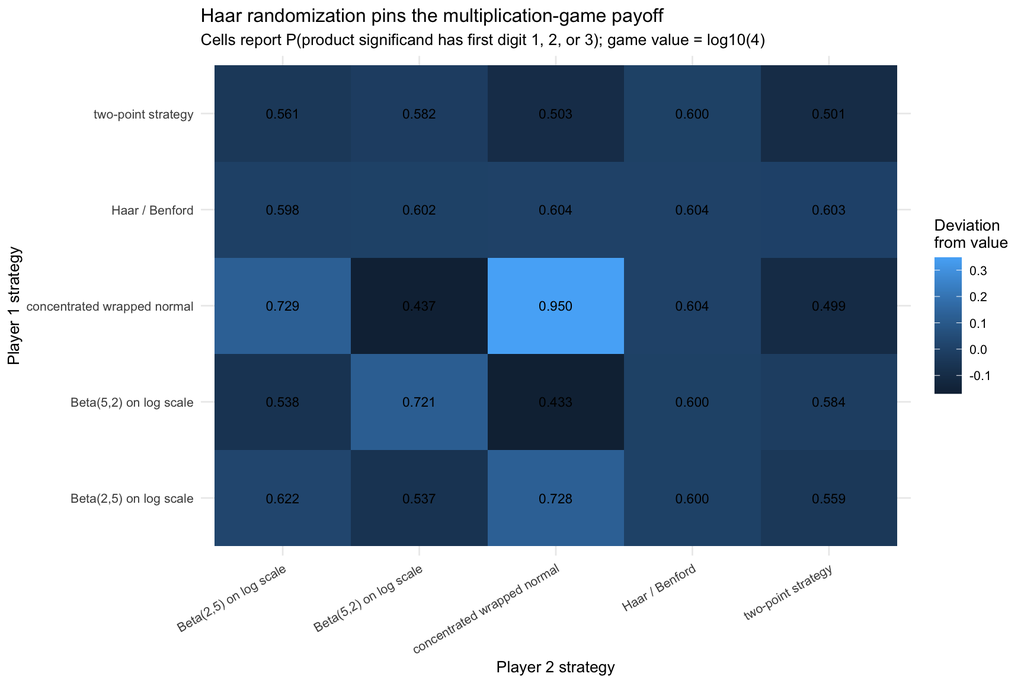

Figure 15: Static multiplication game. Haar/Benford randomization fixes the payoff at the Haar measure of the winning set regardless of the opponent’s mixed strategy.

```r
p_game_static <- plot_static_game_matrix(game_static)
p_game_static
ggplot2::ggsave(
  file.path(fig_dir, "figure_multiplication_game_static.pdf"),
  p_game_static, width = 9, height = 6
)
```

## One-step strategic washout

The next experiment is an elementary dynamic extension, not a claim about equilibrium learning. The initial state is deliberately non-Benford and Player 2 uses a deterministic, state-dependent response. Player 1 then draws a fresh Haar log-action. Translation invariance implies that the next state is exactly uniform conditional on the entire past and on Player 2’s response.

```r
if (isTRUE(params$recompute) || !file.exists(game_washout_file)) {
  game_washout <- run_strategic_washout(n = params$game_washout_n, seed = SEED_GAME_WASHOUT)
  saveRDS(game_washout, game_washout_file)
} else {
  game_washout <- readRDS(game_washout_file)
}

washout_display <- game_washout$summary
names(washout_display) <- c("stage", "chi-square", "p-value", "CvM", "first harmonic")
knitr::kable(washout_display, digits = 6, format = "html")
```

| stage | chi-square | p-value | CvM | first harmonic |
| --- | --- | --- | --- | --- |
| initial state | 78826.665358 | 0.00000 | 6449.250417 | 0.602363 |
| after one Haar move | 4.282378 | 0.83079 | 0.059724 | 0.002564 |

```r
save_latex_table(
  washout_display,
  file.path(tab_dir, "table_game_washout.tex"),
  caption = "One-step strategic washout: an arbitrary state-dependent opponent response is followed by Haar randomization from the other player.",
  label = "tab:game-washout",
  digits = 6
)
```

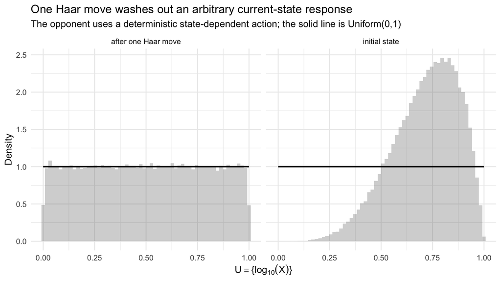

Figure 16: One-step Haar randomization removes the initial non-Benford state distribution despite a state-dependent opponent response.

```r
p_game_washout <- plot_strategic_washout(game_washout)
p_game_washout
ggplot2::ggsave(
  file.path(fig_dir, "figure_game_washout.pdf"),
  p_game_washout, width = 8, height = 4.5
)
```

## Repeated non-Haar play can still mix toward Benford

Finally, both players use fixed, concentrated wrapped-normal mixed strategies on the log scale. Neither action distribution is Haar. Their sum is nevertheless a non-lattice random increment on the circle, and repeated convolution drives the state toward Haar measure. For wrapped-normal actions with standard deviations (_A) and (_B), the magnitude of the first Fourier coefficient decays exactly at rate

[ ^t, ={-2<sup>2(_A</sup>2+_B^2)}. ]

This experiment is included as a mechanism illustration: Benford can describe the induced long-run state even though neither player’s mixed strategy is itself Benford.

```r
if (isTRUE(params$recompute) || !file.exists(game_mixing_file)) {
  game_mixing <- run_nonhaar_repeated_game(
    n_paths = params$game_mixing_paths,
    T = params$game_mixing_rounds,
    seed = SEED_GAME_MIXING
  )
  saveRDS(game_mixing, game_mixing_file)
} else {
  game_mixing <- readRDS(game_mixing_file)
}

knitr::kable(game_mixing$parameters, digits = 6, format = "html")
```

| parameter | value |
| --- | --- |
| mu_A | 0.12000 |
| sigma_A | 0.08000 |
| mu_B | 0.47000 |
| sigma_B | 0.08000 |
| eta | 0.77673 |

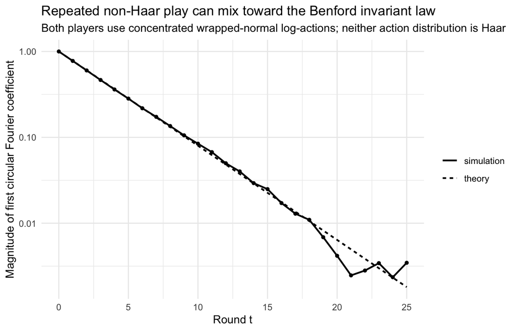

Figure 17: Repeated non-Haar mixed play approaches the Haar/Benford invariant distribution at the predicted Fourier rate.

```r
p_game_mixing <- plot_nonhaar_game_mixing(game_mixing)
p_game_mixing
ggplot2::ggsave(
  file.path(fig_dir, "figure_game_nonhaar_mixing.pdf"),
  p_game_mixing, width = 7, height = 4.5
)
```

# Significand-preserving manipulation

This experiment is deliberately an identification example rather than a realistic model of a particular fraud scheme. Starting from

[ X_t=10^{K_t+U_t}, ]

we independently flag a fraction (q) of observations and shift their order of magnitude by an integer amount:

[ X_t’=10^{K_t+_t+U_t}. ]

The entire significant-digit sequence is therefore unchanged observation by observation.

```r
if (isTRUE(params$recompute) || !file.exists(manipulation_file)) {
  manipulation <- run_manipulation_experiment(
    n = params$n_seq * params$seq_len,
    q = params$manipulation_q,
    shift_orders = params$manipulation_shift_orders,
    K_fourier = params$K_fourier,
    seed = SEED_MANIPULATION
  )
  saveRDS(manipulation, manipulation_file)
} else {
  manipulation <- readRDS(manipulation_file)
}

stopifnot(isTRUE(manipulation$exact_u_identity))

manip_names <- c(chisq = "chi-square", cvm = "CvM", B_K = "B(K)")
manip_table <- data.frame(
  statistic = unname(manip_names[names(manipulation$before)]),
  original = as.numeric(manipulation$before),
  manipulated = as.numeric(manipulation$after),
  difference = as.numeric(manipulation$after - manipulation$before)
)
knitr::kable(manip_table, digits = 12, format = "html")
```

| statistic | original | manipulated | difference |
| --- | --- | --- | --- |
| chi-square | 1.357393e+01 | 1.357393e+01 | 0 |
| CvM | 3.482946e-01 | 3.482946e-01 | 0 |
| B(K) | 9.960535e-05 | 9.960535e-05 | 0 |

```r
save_latex_table(
  manip_table,
  file.path(tab_dir, "table_manipulation_digits.tex"),
  caption = "Significand-only statistics before and after an order-of-magnitude manipulation. The statistics are identical by construction.",
  label = "tab:manipulation-digits",
  digits = 12
)
```

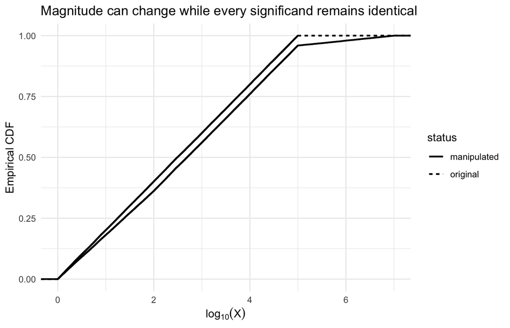

Figure 18: The manipulation changes magnitude while leaving all significant digits unchanged.

```r
p_man <- plot_manipulation_magnitudes(manipulation)
p_man
ggplot2::ggsave(
  file.path(fig_dir, "figure_manipulation_magnitudes.pdf"),
  p_man, width = 7, height = 4.5
)
```